# Exercise 1 - Seurat

Rockefeller University, Bioinformatics Resource Centre

https://rockefelleruniversity.github.io/scRNA-seq

These exercises are about manipulate single-cell data with Seurat. Please download the counting matrix from [DropBox](https://www.dropbox.com/sh/ztu0pucvu21szxm/AABGUhTryKp1T1CsoEUFRPcwa?dl=0) and loading them into a Seurat object. Or you may also used the rds file *data/scSeq_CKO_1kCell_ori.rds*.

## **Exercise 1** - **Data manipulation with Seurat**

### Loading data

1. Create a Seurat object by reading the count data from BOX or by loading the rds file. Then calculate mitochondrial contents of each ell

```r
library(Seurat)
obj <- readRDS("data/scSeq_CKO_1kCell_ori.rds")
obj[["percent.mt"]] <- PercentageFeatureSet(obj, pattern = "^mt-")
head(obj@meta.data)
```

```
##                        orig.ident nCount_RNA nFeature_RNA dset percent.mt
## CKO_AGACGTTCAGCTGGCT-1        CKO       2679         1200  CKO  0.1119821
## CKO_TTAACTCGTAGTACCT-1        CKO        813          476  CKO 14.3911439
## CKO_GAGGTGAGTCTAGTGT-1        CKO       4852         1759  CKO 10.9233306
## CKO_CTCGTACAGCTAAGAT-1        CKO       1750          672  CKO 46.0000000
## CKO_AGGGAGTTCAAACCAC-1        CKO       4632         1585  CKO  5.3108808
## CKO_ATTATCCTCAACGGCC-1        CKO       2498         1177  CKO  3.8030424
```

### Basic QC

2. Access the read counts (nCount_RNA), gene counts (nFeature_RNA), and mitochondrial content (percent.mt) for each cell and draw a violin plot of each.

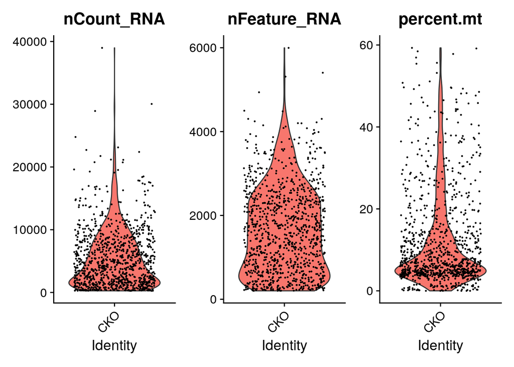

```r
VlnPlot(obj,features = c("nCount_RNA","nFeature_RNA","percent.mt"),pt.size = 0.2)
```

3. Mmake a dot plot for nCount_RNA vs nFeature_RNA. *NOTE: At this step try to keep an eye out potential doublets.*

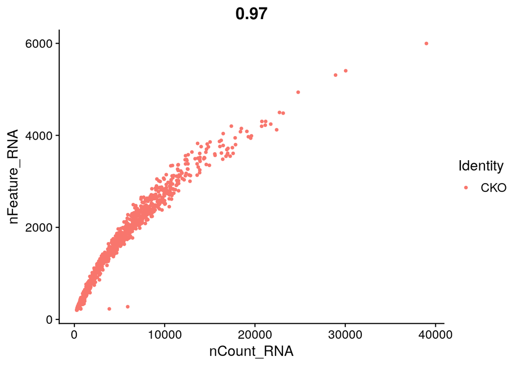

```r
FeatureScatter(obj,feature1="nCount_RNA",feature2="nFeature_RNA")
```

4. Make a dot plot for nCount_RNA vs percent.mt. *NOTE: At this step try to keep an eye out potential cell debris.*

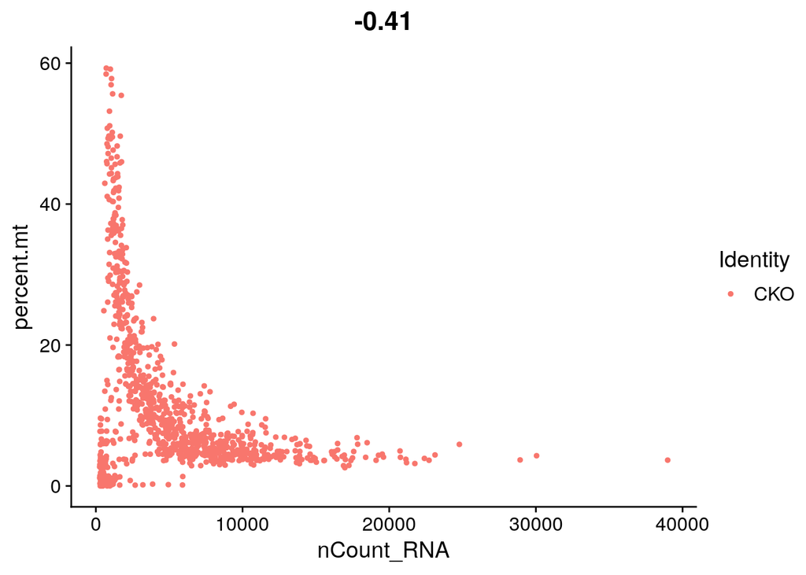

```r
FeatureScatter(obj,feature1="nCount_RNA",feature2="percent.mt")
```

5. Remove cells with percent.mt >= 10 for following analysis

```r
mt_cutH <- 10
obj_unfiltered <- obj
obj <- subset(obj,subset = percent.mt < mt_cutH)
obj
```

```
## An object of class Seurat
## 14353 features across 619 samples within 1 assay
## Active assay: RNA (14353 features, 0 variable features)
```

### Cell cycle

6. Please estimate cell cycle phase of each cell and make a table to describe how many cells per phase.

```r
convertHumanGeneList <- function(x){
  require("biomaRt")
  human = useMart("ensembl", dataset = "hsapiens_gene_ensembl",host = "http://useast.ensembl.org")
  mouse = useMart("ensembl", dataset = "mmusculus_gene_ensembl",host = "http://useast.ensembl.org")
  genesV2 = getLDS(attributes = c("hgnc_symbol"),
                   filters = "hgnc_symbol",
                   values = x ,
                   mart = human,
                   attributesL = c("mgi_symbol"),
                   martL = mouse, uniqueRows=T)
  humanx <- unique(genesV2[, 2])
  return(humanx)}
#
s_gene <- convertHumanGeneList(cc.genes$s.genes)
g2m_gene <- convertHumanGeneList(cc.genes$g2m.genes)
#
obj <- CellCycleScoring(obj, s.features = s_gene,
                              g2m.features = g2m_gene, set.ident = TRUE)
table(obj@meta.data$Phase)
```

```
##
##  G1 G2M   S
## 260 108 251
```

### Normalization and clustering

7. Please scale data regressing to mitochondrial content (percent.mt) and cell cycle (S.score, G2M.score, Phase).

```r
obj <- FindVariableFeatures(obj)
obj <- ScaleData(obj,vars.to.regress = c("percent.mt","S.score","G2M.score","Phase"))
```

8. Please make principle component analysis (PCA), estimate how many PCs would best represent this data, then make clustering and UMAP plot.
- check for up to 30 PCs.
- elbow plot can be used to determine PCs.

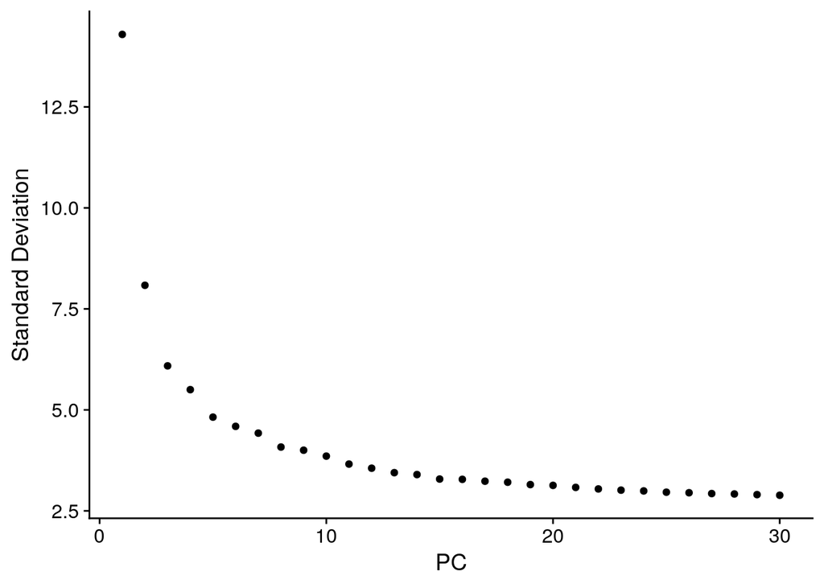

```r
set.seed(0)
obj <- RunPCA(obj, npcs = 30, verbose = FALSE)
ElbowPlot(obj,ndims = 30)
```

```r
#
numPC <- 10
maxPC <- numPC
obj <- FindNeighbors(obj, reduction = "pca", dims = 1:maxPC)
obj <- FindClusters(obj, resolution = 0.5)
```

```
## Modularity Optimizer version 1.3.0 by Ludo Waltman and Nees Jan van Eck
##
## Number of nodes: 619
## Number of edges: 17846
##
## Running Louvain algorithm...
## Maximum modularity in 10 random starts: 0.8145
## Number of communities: 6
## Elapsed time: 0 seconds
```

```r
#
obj <- RunUMAP(obj, reduction = "pca", dims = 1:maxPC)
```

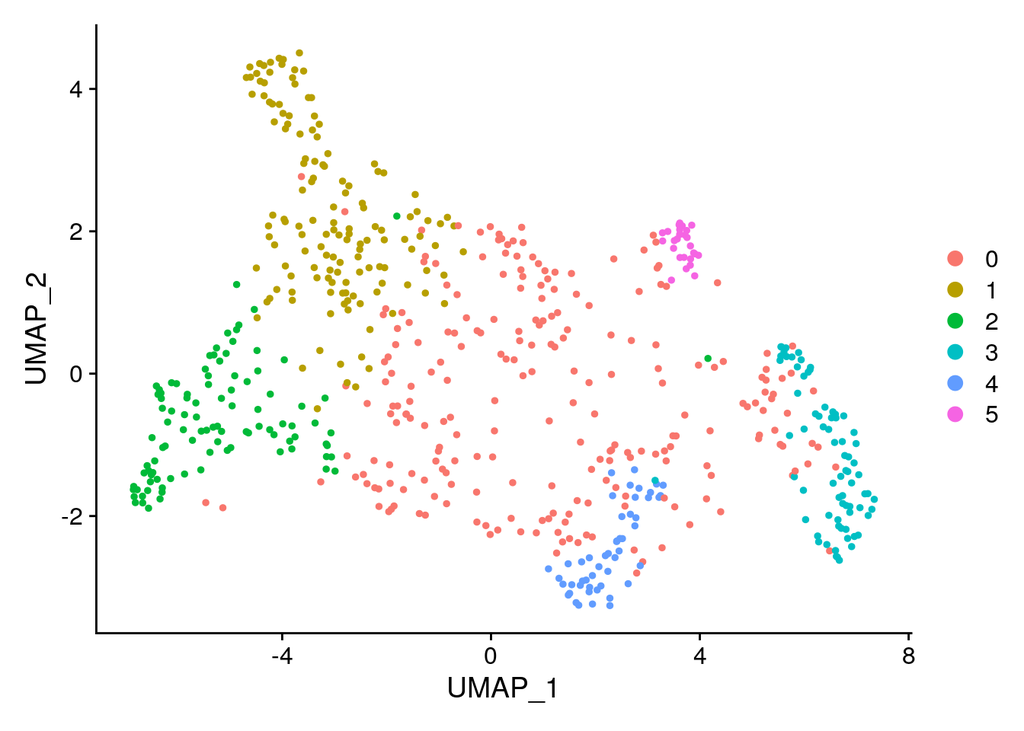

```r
obj <- RunTSNE(obj, reduction = "pca", dims = 1:maxPC)
#
DimPlot(obj,reduction = "umap")
```

### Marker genes

9. Try to select marker genes for each cluster and generate a heatmap of the top five marker genes for each cluster.

```r
obj <- SetIdent(obj,value = "seurat_clusters")
clust.markers <- FindAllMarkers(obj,
                                only.pos = TRUE,
                                min.pct = 0.25,
                                logfc.threshold = 0.25)
head(clust.markers)
```

```
##                 p_val avg_log2FC pct.1 pct.2    p_val_adj cluster     gene
## Dcn      5.248586e-28  3.6236022 0.832 0.434 7.533296e-24       0      Dcn
## Tnfrsf19 9.893203e-16  0.6278188 0.621 0.271 1.419971e-11       0 Tnfrsf19
## Kremen2  1.517087e-15  1.6636156 0.703 0.377 2.177475e-11       0  Kremen2
## Ifitm3   1.519477e-13  3.6505185 0.871 0.638 2.180906e-09       0   Ifitm3
## Lef1     9.500305e-13  1.7603907 0.513 0.222 1.363579e-08       0     Lef1
## Postn    2.547487e-12  1.6586465 0.599 0.320 3.656408e-08       0    Postn
```

[figure not shown]

```r
#
topG <- clust.markers %>%
  group_by(cluster) %>%
  top_n(n = 5, wt = avg_log2FC)
#
DoHeatmap(obj, features = topG$gene) + NoLegend()
```

### Advanced plots

10. Please display the top marker gene of each cluster in FeaturePlot and RidgePlot

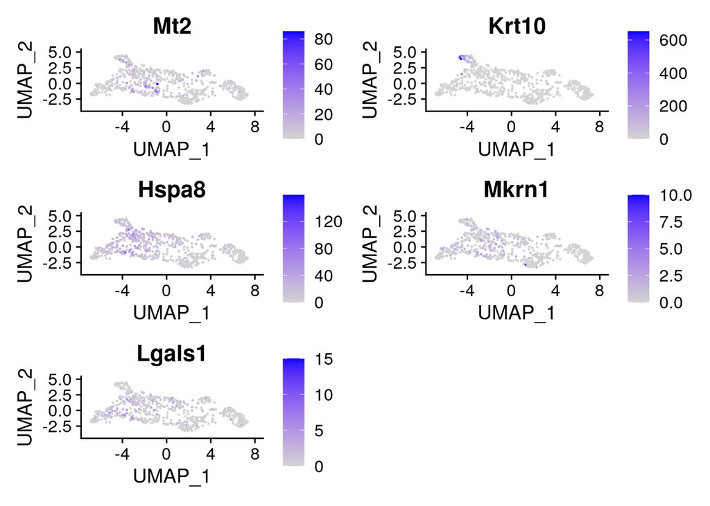

```r
topG <- clust.markers %>%
  group_by(cluster) %>%
  top_n(n = 1, wt = avg_log2FC)
top_gene <- topG$gene
#
FeaturePlot(obj,features = top_gene,pt.size = 0.2)
```

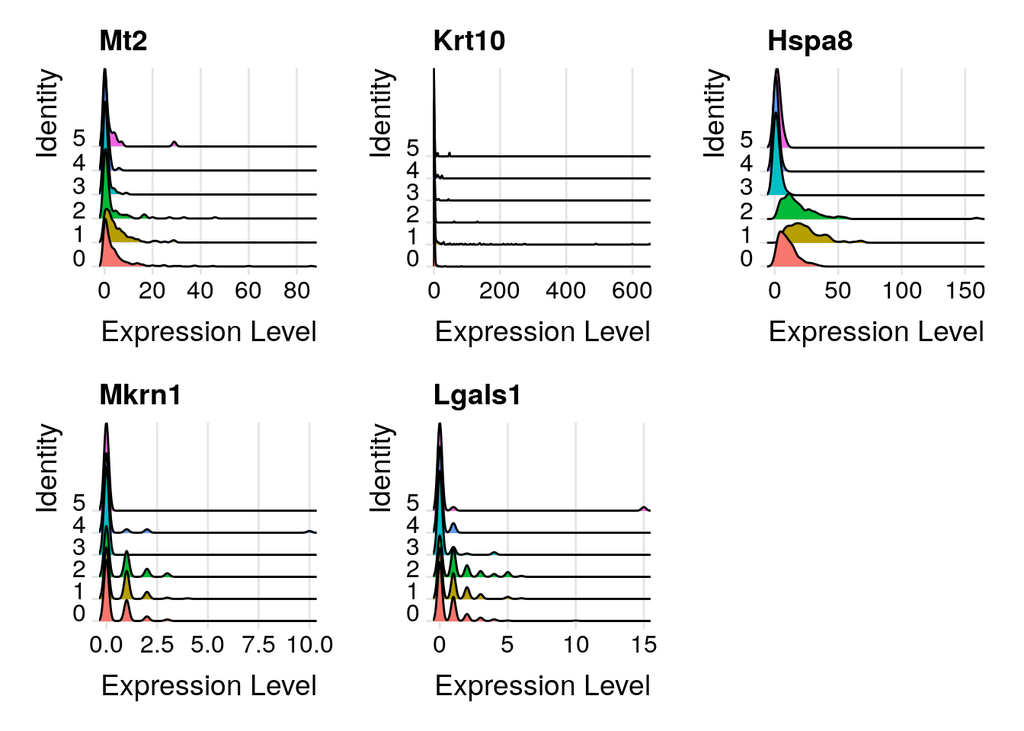

```r
RidgePlot(obj,features = top_gene)
```